# In-house training for UAMECO lab

We will need some abiotic data as well, so let’s download them too from [GitHub](https://github.com/kostask84/EKPA_In_house_practicals/tree/master)

# 1 **First steps**

## 1.1 **Library installation**

```r
## CRAN repository:
install.packages("easypackages", repos = "http://cran.us.r-project.org")
```

## 1.2 **Load a library**

Loading a package/library

```r
library(easypackages)
```

```r
libraries("rio", "car", "MASS", "psych", "leaps", "ggplot2", "klaR", "DiscriMiner",
    "dplyr", "car", "MASS", "corrgram", "tidyverse", "plyr")
```

## 1.3 **Load some data**

We are going to work with data already existing in R for now.

```r
data(iris)
```

```r
names(iris)
```

```
## [1] "Sepal.Length" "Sepal.Width"  "Petal.Length" "Petal.Width"
## [5] "Species"
```

```r
head(iris)
```

```
##   Sepal.Length Sepal.Width Petal.Length Petal.Width Species
## 1          5.1         3.5          1.4         0.2  setosa
## 2          4.9         3.0          1.4         0.2  setosa
## 3          4.7         3.2          1.3         0.2  setosa
## 4          4.6         3.1          1.5         0.2  setosa
## 5          5.0         3.6          1.4         0.2  setosa
## 6          5.4         3.9          1.7         0.4  setosa
```

```r
str(iris)
```

```
## 'data.frame':    150 obs. of  5 variables:
##  $ Sepal.Length: num  5.1 4.9 4.7 4.6 5 5.4 4.6 5 4.4 4.9 ...
##  $ Sepal.Width : num  3.5 3 3.2 3.1 3.6 3.9 3.4 3.4 2.9 3.1 ...
##  $ Petal.Length: num  1.4 1.4 1.3 1.5 1.4 1.7 1.4 1.5 1.4 1.5 ...
##  $ Petal.Width : num  0.2 0.2 0.2 0.2 0.2 0.4 0.3 0.2 0.2 0.1 ...
##  $ Species     : Factor w/ 3 levels "setosa","versicolor",..: 1 1 1 1 1 1 1 1 1 1 ...
```

```r
iris$Species
```

```
##  [1] setosa     setosa     setosa     setosa     setosa     setosa
##  [7] setosa     setosa     setosa     setosa     setosa     setosa
## [13] setosa     setosa     setosa     setosa     setosa     setosa
## [19] setosa     setosa     setosa     setosa     setosa     setosa
## [25] setosa     setosa     setosa     setosa     setosa     setosa
## [31] setosa     setosa     setosa     setosa     setosa     setosa
## [37] setosa     setosa     setosa     setosa     setosa     setosa
## [43] setosa     setosa     setosa     setosa     setosa     setosa
## [49] setosa     setosa     versicolor versicolor versicolor versicolor
## [55] versicolor versicolor versicolor versicolor versicolor versicolor
## [61] versicolor versicolor versicolor versicolor versicolor versicolor
## [67] versicolor versicolor versicolor versicolor versicolor versicolor
## [73] versicolor versicolor versicolor
##  [ reached getOption("max.print") -- omitted 75 entries ]
## Levels: setosa versicolor virginica
```

Let’s change the species’ names:

```r
iris$Species <- revalue(iris$Species, c(setosa = "Iris setosa", virginica = "Iris virginica",
    versicolor = "Iris versicolor"))
```

## 1.4 **Less decimals**

```r
options(digits = 2)
```

## 1.5 **Some basic statistics for each taxon**

Let’s take a look at some very basic stats (e.g., mean, min, max, sd):

```r
iris %>% split(.$Species) %>% map(~summary(.))
```

```
## $`Iris setosa`
##   Sepal.Length  Sepal.Width   Petal.Length   Petal.Width
##  Min.   :4.3   Min.   :2.3   Min.   :1.00   Min.   :0.10
##  1st Qu.:4.8   1st Qu.:3.2   1st Qu.:1.40   1st Qu.:0.20
##  Median :5.0   Median :3.4   Median :1.50   Median :0.20
##  Mean   :5.0   Mean   :3.4   Mean   :1.46   Mean   :0.25
##  3rd Qu.:5.2   3rd Qu.:3.7   3rd Qu.:1.57   3rd Qu.:0.30
##  Max.   :5.8   Max.   :4.4   Max.   :1.90   Max.   :0.60
##             Species
##  Iris setosa    :50
##  Iris versicolor: 0
##  Iris virginica : 0
##
##
##
##
## $`Iris versicolor`
##   Sepal.Length  Sepal.Width   Petal.Length  Petal.Width
##  Min.   :4.9   Min.   :2.0   Min.   :3.0   Min.   :1.00
##  1st Qu.:5.6   1st Qu.:2.5   1st Qu.:4.0   1st Qu.:1.20
##  Median :5.9   Median :2.8   Median :4.3   Median :1.30
##  Mean   :5.9   Mean   :2.8   Mean   :4.3   Mean   :1.33
##  3rd Qu.:6.3   3rd Qu.:3.0   3rd Qu.:4.6   3rd Qu.:1.50
##  Max.   :7.0   Max.   :3.4   Max.   :5.1   Max.   :1.80
##             Species
##  Iris setosa    : 0
##  Iris versicolor:50
##  Iris virginica : 0
##
##
##
##
## $`Iris virginica`
##   Sepal.Length  Sepal.Width   Petal.Length  Petal.Width
##  Min.   :4.9   Min.   :2.2   Min.   :4.5   Min.   :1.40
##  1st Qu.:6.2   1st Qu.:2.8   1st Qu.:5.1   1st Qu.:1.80
##  Median :6.5   Median :3.0   Median :5.5   Median :2.00
##  Mean   :6.6   Mean   :3.0   Mean   :5.6   Mean   :2.03
##  3rd Qu.:6.9   3rd Qu.:3.2   3rd Qu.:5.9   3rd Qu.:2.30
##  Max.   :7.9   Max.   :3.8   Max.   :6.9   Max.   :2.50
##             Species
##  Iris setosa    : 0
##  Iris versicolor: 0
##  Iris virginica :50
##
##
##
```

```r
DiscriMiner::groupStds(iris[, 1:4], iris[, 5])
```

```
##              Iris setosa Iris versicolor Iris virginica
## Sepal.Length        0.35            0.52           0.64
## Sepal.Width         0.38            0.31           0.32
## Petal.Length        0.17            0.47           0.55
## Petal.Width         0.11            0.20           0.27
```

## 1.6 **Graphical outpout**

Let’s plot our data for each taxon and a single variable:

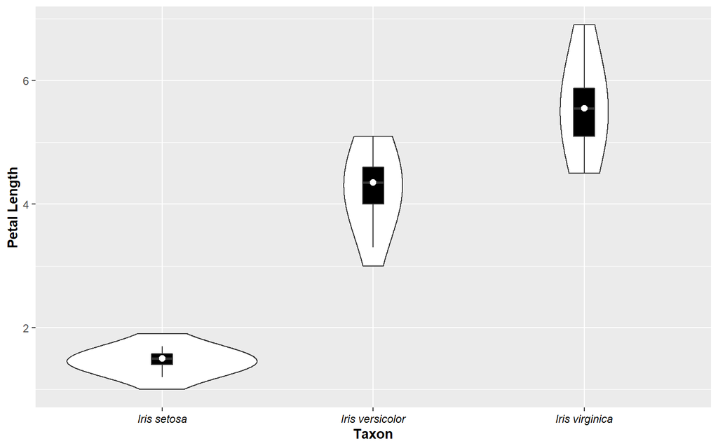

```r
## Violin plot
ggplot(iris, aes(Species, Petal.Length)) + geom_violin(adjust = 4) + geom_boxplot(width = 0.1,
    fill = "black", outlier.colour = NA) + stat_summary(fun.y = median, geom = "point",
    fill = "white", shape = 21, size = 2.5) + xlab("Taxon") + ylab("Petal Length") +
    theme(axis.title = element_text(face = "bold"), axis.text.x = element_text(face = "italic",
        colour = "black"))
```

```r
ggsave("Petal length.png", width = 20, height = 20, units = "cm", dpi = 600)
```

> You can play around with the rest of the variables if you want.

# 2 **Main morphometric analysis**

We can now proceed to the first step of the main analysis:

```r
##===========================================================================##
## If you are going to use this bit for your own analyses, the only thing you
## will have to change is the name of the dataset (here: iris) and the name of
## the variables
##===========================================================================##

attach(iris)

iris <- iris[apply(iris,1,function(row) all(!is.na(row))),]


set.seed(2934) ## Change that if you want to whichever number you like

cv.grp <- sample(1:10, nrow(iris),
                 replace = TRUE)

cv.lda <- c() ##A function that splits our data to 2 independent subsets, one to
              ## train our model and one to test how well our model behaves

for(i in 1:10) {
  train.ind <- which(cv.grp!=i)
  test.ind <- which(cv.grp==i)
  model.train <- lda(Species ~ Sepal.Length +

  Sepal.Width + Petal.Width + Petal.Length,
  data = iris, subset = train.ind)
  cv.lda[test.ind] <- predict(model.train,
  newdata = iris[test.ind,])$class
 }

mean(cv.lda==as.numeric(iris$Species))
```

```
## [1] 0.98
```

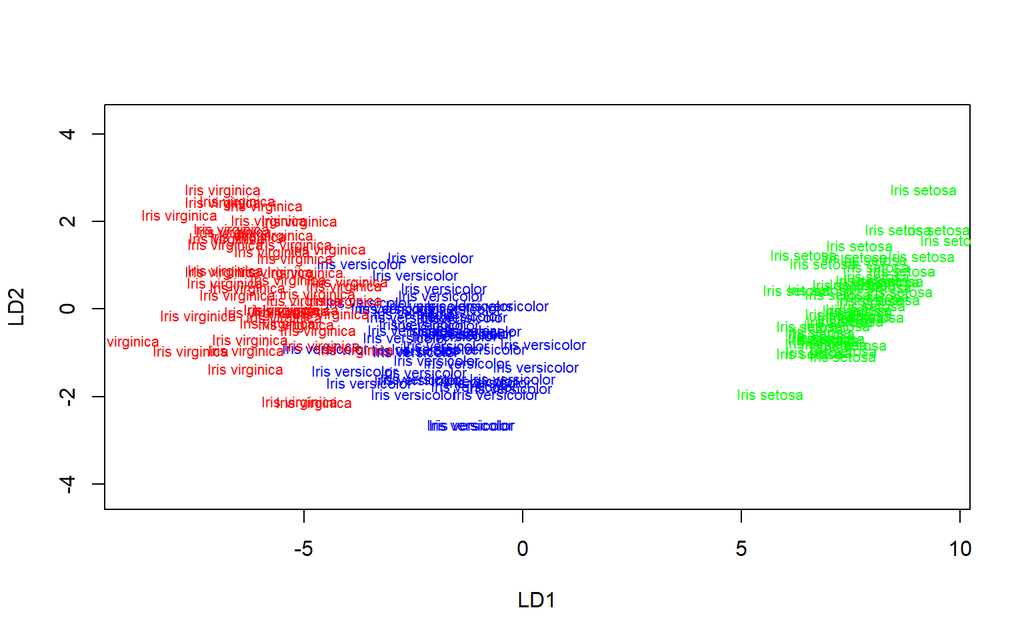

```r
Lec.lda <- lda(Species ~ Sepal.Length +
Sepal.Width + Petal.Width + Petal.Length,

data = iris)


plot(Lec.lda,col = c("green","blue","red")

[iris$Species], pch = 19)
```

Let’s see the result:

```r
Lec.lda


## Let's see what we did
##--------------------------------------------------------------------------------##
# Call: lda(Species ~ Sepal.Length + Sepal.Width + Petal.Width +
# Petal.Length, data = iris)
##--------------------------------------------------------------------------------##
## How much of the data lie in each species

## Prior probabilities of groups:

## setosa versicolor virginica

## 0.33 0.33 0.33
##--------------------------------------------------------------------------------##

## Group means:

## Sepal.Length Sepal.Width Petal.Width Petal.Length

## setosa 5.0 3.4 0.25 1.5

## versicolor 5.9 2.8 1.33 4.3

## virginica 6.6 3.0 2.03 5.6
##--------------------------------------------------------------------------------##

## Coefficients of linear discriminants:

## LD1 LD2

## Sepal.Length 0.83 0.024

## Sepal.Width 1.53 2.165

## Petal.Width -2.81 2.839

## Petal.Length -2.20 -0.932

##--------------------------------------------------------------------------------##

## Proportion of trace:

## The most important part

## It shows how many discriminant axes are there and which is the most
## important in order to distinguish the taxa

## The axes are like this: a*x1 + b*x2 We get a & b from the Coefficients of
## linear discriminants


## (here: 0.83*Sepal.Length + 1.53*Sepal.Width - 2.81*Petal.Width -
## 2.20*Petal.Length for the first axis)


## We can see them with: Lec.lda$scaling
##--------------------------------------------------------------------------------##

## LD1 LD2

## 0.9912 0.0088

## LD1 is the most important as it explains 99,12%
##--------------------------------------------------------------------------------##
```

## 2.1 **Importance of each discriminant axis in relation to the rest of the axes**

The greater the ratio, the more important (more diagnostic) the numerator:

```r
SVD <- Lec.lda$svd
SVD
```

```
## [1] 48.6  4.6
```

## 2.2 **Correlation of the morphological characters with each discriminant axis**

We are going to use the `predict` and `cor` functions for this part. If in your analysis, you have more than two discriminant axes, all you’ll have to do is just add as many more lines as your additional axes in the code below:

```r
LD1 <- predict(Lec.lda)$x[, 1]
LD2 <- predict(Lec.lda)$x[, 2]

## ===========================================================================##
## We will see which variable is the most important for each axis We are
## interested in the absolute value
## ===========================================================================##
cor(iris[, 1:4], LD1)
```

```
##                    [,1]
## Sepal.Length -0.7918878
## Sepal.Width   0.5307590
## Petal.Length -0.9849513
## Petal.Width  -0.9728120
```

```r
cor(iris[, 1:4], LD2)
```

```
##                    [,1]
## Sepal.Length 0.21759312
## Sepal.Width  0.75798931
## Petal.Length 0.04603709
## Petal.Width  0.22290236
```

## 2.3 **Correct classification table**

We now want to see how well the morphological characters that have emerged as important can discriminate between the taxa:

```r
x <- Lec.lda
y <- predict(x, iris)

detach(iris)  ## DON'T FORGET TO DO THAT

round(100 * errormatrix(iris$Species, y$class, relative = T), 1)
```

[output not shown]

## 2.4 **Importance of each morphological character**

We can check which is the most important morphological character:

```r
## ===========================================================================##
## The smaller the Wilk's lambda, the better
## ===========================================================================##
klaR::greedy.wilks(Species ~ Sepal.Length + Sepal.Width + Petal.Width + Petal.Length,
    data = iris, niveau = 0.1)
```

```
## Formula containing included variables:
##
## Species ~ Petal.Length + Sepal.Width + Petal.Width + Sepal.Length
## <environment: 0x0000000023139388>
##
##
## Values calculated in each step of the selection procedure:
##
##           vars Wilks.lambda F.statistics.overall p.value.overall
## 1 Petal.Length   0.05862828            1180.1612    2.856777e-91
## 2  Sepal.Width   0.03688411             307.1047   2.848870e-103
## 3  Petal.Width   0.02497554             257.5032   5.036981e-113
## 4 Sepal.Length   0.02343863             199.1453   1.365006e-112
##   F.statistics.diff p.value.diff
## 1       1180.161182 2.856777e-91
## 2         43.035453 1.998401e-15
## 3         34.568686 5.122569e-13
## 4          4.721152 1.031871e-02
```

## 2.5 **Graphical outpout**

```r
## ===========================================================================##
## Store in a vector (and then in a dataframe the LDA result)
## ===========================================================================##
s <- predict(Lec.lda)$x
s <- as.data.frame(s)
## ===========================================================================##


## ===========================================================================##
## Create a vector containing the name of the taxa
## ===========================================================================##
Taxon <- factor(iris$Species)
## ===========================================================================##


## ===========================================================================##
## Bind those two vectors in a single dataframe
## ===========================================================================##
s <- cbind(Taxon, s)
## ===========================================================================##


## ===========================================================================##
## Check the result
## ===========================================================================##
head(s, 1)
```

```
##         Taxon    LD1       LD2
## 1 Iris setosa 8.0618 0.3004206
```

```r
names(s)
```

```
## [1] "Taxon" "LD1"   "LD2"
```

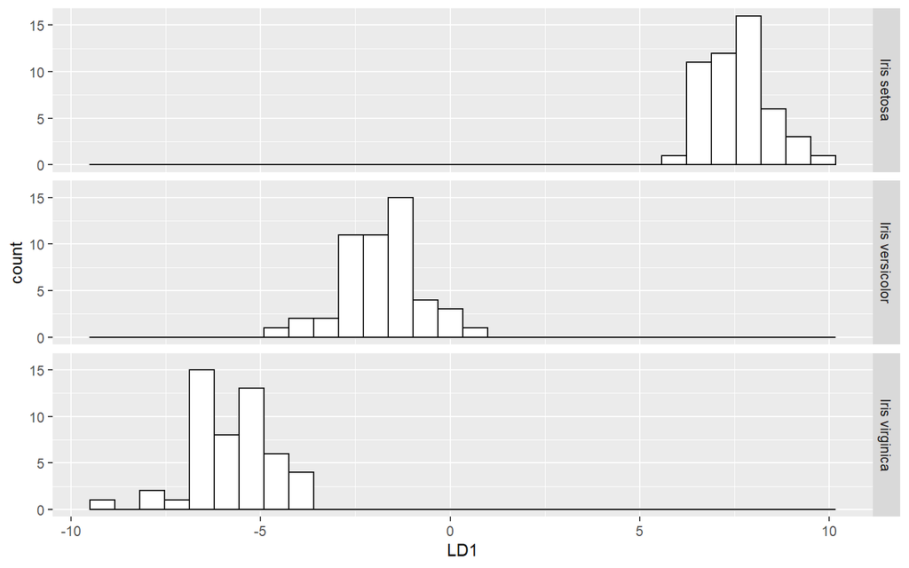

```r
## ===========================================================================##
## Plot the first discriminant axis and save it
## ===========================================================================##
ggplot(s, aes(x = LD1)) + geom_histogram(fill = "white", colour = "black") +
    facet_grid(Taxon ~ .)
```

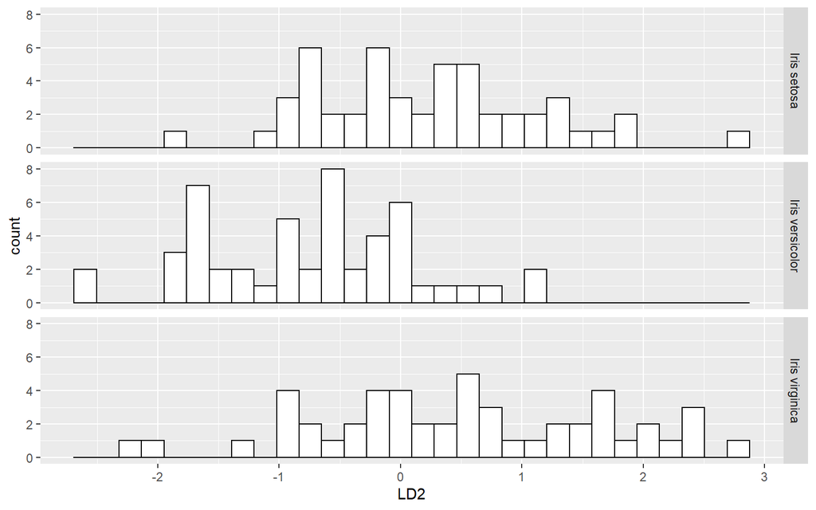

```r
ggsave("Iris LD1.png", width = 20, height = 20, units = "cm", dpi = 600)


## ===========================================================================##
## Do the same for the other axes as well
## ===========================================================================##
ggplot(s, aes(x = LD2)) + geom_histogram(fill = "white", colour = "black") +
    facet_grid(Taxon ~ .)
```

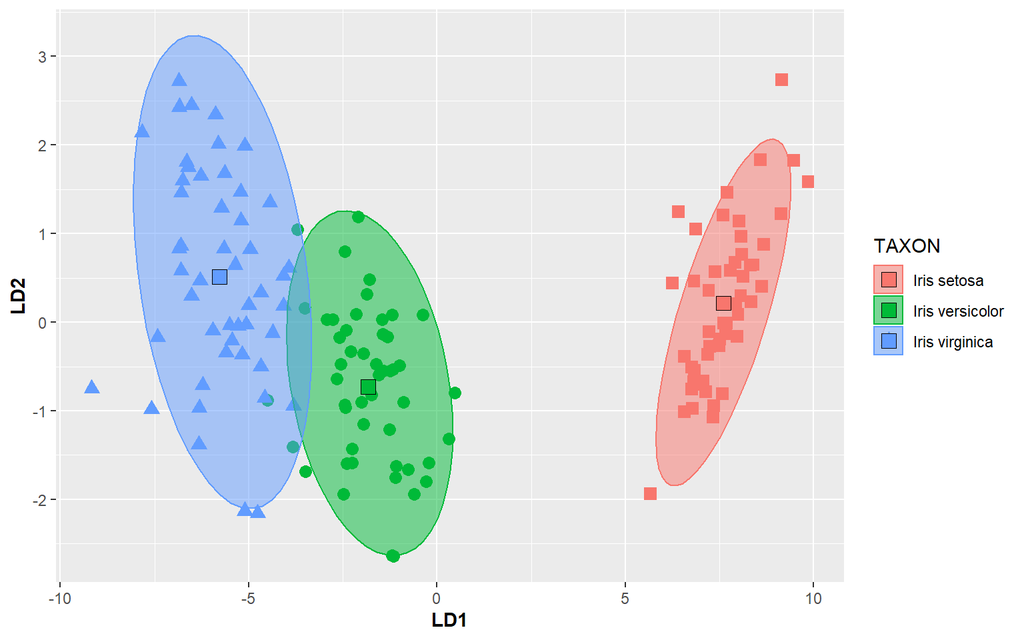

```r
ggsave("Iris LD2.png", width = 20, height = 20, units = "cm", dpi = 600)


## ===========================================================================##
## Create some vectors containing the values from the discriminant axes
## ===========================================================================##
a <- s$LD1
b <- s$LD2
TAXON <- iris$Species
## ===========================================================================##


## ===========================================================================##
## Create a dataframe that contains all the above
## ===========================================================================##
g <- data.frame(TAXON, a, b)
## ===========================================================================##


## ===========================================================================##
## Another dataframe containing the centroids for each species and each
## discriminant axis
## ===========================================================================##
centroids <- aggregate(cbind(a, b) ~ TAXON, g, mean)
## ===========================================================================##


## ===========================================================================##
## Plot the result
## ===========================================================================##
ggplot(g, aes(a, b, color = TAXON, shape = TAXON)) + geom_point(size = 3) +
    stat_ellipse(geom = "polygon", alpha = 1/2, aes(fill = TAXON)) + xlab("LD1") +
    ylab("LD2") + theme(axis.title = element_text(face = "bold")) + stat_summary(data = centroids,
    fun.y = "mean", geom = "point", shape = 22, size = 4, colour = "black",
    aes(fill = TAXON)) +
## Shape of each species

## If you have more than 3 species you must add some values (range: 10-20)
scale_shape_manual(values = c(15, 16, 17))
```

```r
## ===========================================================================##
## Save it in a png
## ===========================================================================##
ggsave("Iris ellipses.png", width = 20, height = 20, units = "cm", dpi = 600)
```

# 3 **Niche differentiation tests**

Apart from phenotypic differences/similarities, species might be different/similar regarding their niche requirements. According to the [Phylogenetic Niche Conservatism hypothesis](https://www.ncbi.nlm.nih.gov/pmc/articles/PMC4558954/), closely related species tend to occupy similar niches (Pyron et al., 2015). But that’s not always the case. By combining molecular/genetic, morphological and ecological data, we can gain valuable insights regarding the taxonomic status of the species we are interested in (e.g., [here](https://link.springer.com/article/10.1007/s10336-019-01702-6), [here](https://www.ingentaconnect.com/contentone/botbel/plecevo/2019/00000152/00000001/art00005?crawler=true&mimetype=application/pdf), [here](https://peerj.com/articles/7384/) and [here](https://nph.onlinelibrary.wiley.com/doi/pdf/10.1111/nph.15663?casa_token=YRGpjEUQitcAAAAA:Aw_ROp-GoOxX3zkGJT0ln5ckk6cBdNV_b2C0wlTXq2K-M6GV7N7kU83W1vBvHGtuKGkduFxrupXC)). One another really cool type of analysis (if we have phylogenetic data), is [phyloclimatic modeling](https://academic.oup.com/sysbio/article/55/5/785/1666006) (e..g, [one example](https://bmcevolbiol.biomedcentral.com/articles/10.1186/1471-2148-6-72) and [another one](https://onlinelibrary.wiley.com/doi/pdf/10.1111/jbi.13233?casa_token=73zkVio3EaIAAAAA:LrTiKZwIsMhbzaJCdZMi7eHhf8ckWFD8O89JS4sas02N37WX0Y42wYcb-y7QWe6ct61qwiU0TJRR)). Today, we are not going to delve into that though, we are just going to scratch the surface of niche divergence/similarity. We are going to use some data from three plant taxa (for the sake of continuity, I gave them the same names as in the previous part of this practical).

## 3.1 **Load the required libraries**

```r
## ============================================================================##
## Load the libraries ----
## ============================================================================##
pacman::p_load(magrittr, raster, dplyr, RStoolbox, hypervolume, usdm, ecospat,
    stringr, spatialEco, sf, fasterize, doParallel)
## ============================================================================##
```

## 3.2 **Load the biotic and abiotic data**

First, let’s load the biotic data (the species’ occurrences)[^1]:

```r
iris_EKPA <- readxl::read_excel("G:/Academic/Lessons/EMB/Labs/Labs/TRUE RMD Files/EKPA/Iris EKPA.xlsx")
```

Then, let’s load the abiotic data[^2]:

```r
predictors_final <- readRDS("G:/Academic/Lessons/EMB/Labs/Labs/TRUE RMD Files/EKPA/Predictors.rds")
```

> Obviously the three *Iris* taxa are not endemic in Crete…

## 3.3 **Subset the abiotic data**

Let’s agree that the abiotic data we have can adequately delineate the ecological niche of the species in question. We have to check whether these environmental variables are colinear or not and then go on with the rest of the analysis.

```r
vifcor(as.data.frame(predictors_final), th = 0.7)
```

[output not shown]

After checking for colinearity, we can subset our abiotic data:

```r
predictors_subset <- predictors_final[[c(3, 13, 15, 20:22, 43:47, 49, 51:54,
    57)]]
```

## 3.4 **Reduce the dimensionality**

For this analysis, we need to reduce the dimensionality of our uncorrelated, abiotic data. We will run a PCA for that and we will scale the PCA axes, so as to be comparable:

```r
predictors_pca <- rasterPCA(predictors_subset, 10000, 2)
predictors_pca <- scale(predictors_pca$map)
```

## 3.5 **Subset the biotic data**

Now, we need to create three dataframes containing the occurrences for each taxon:

```r
coords_setosa <- iris_EKPA %>% filter(str_detect(Taxon, "setosa$"))

coords_versicolor <- iris_EKPA %>% filter(str_detect(Taxon, "versicolor$"))

coords_virginica <- iris_EKPA %>% filter(str_detect(Taxon, "virginica$"))
```

## 3.6 **Extract PCA data**

As a next step, we are going to extract the PCA values for each taxon, convert that to a dataframe and make sure that any `NA` data are converted to `zeros`:

```r
## ============================================================================##
## Convert the occs to spatial objects
## ============================================================================##
coordinates(coords_setosa) <- c("lon", "lat")
coordinates(coords_versicolor) <- c("lon", "lat")
coordinates(coords_virginica) <- c("lon", "lat")
## ============================================================================##


## ============================================================================##
## Extract PCA data and convert to dataframes
## ============================================================================##
dianthus_setosa_clim <- extract(predictors_pca, coords_setosa) %>% as.data.frame()

dianthus_versicolor_clim <- extract(predictors_pca, coords_versicolor) %>% as.data.frame()

dianthus_virginica_clim <- extract(predictors_pca, coords_virginica) %>% as.data.frame()
## ============================================================================##


## ============================================================================##
## Eliminate any NA data
## ============================================================================##
dianthus_setosa_clim[is.na(dianthus_setosa_clim)] <- 0
dianthus_versicolor_clim[is.na(coords_versicolor)] <- 0
dianthus_virginica_clim[is.na(dianthus_virginica_clim)] <- 0
## ============================================================================##
```

We need to convert the species names in the format `ecospat` wants to:

```r
## ============================================================================##
## Create a dataframe as required by ecospat -----
## ============================================================================##
coords_ecospat <- iris_EKPA %>% mutate(species = ifelse(Taxon == "Iris setosa",
    "sp1", ifelse(Taxon == "Iris versicolor", "sp2", "sp3"))) %>% as.data.frame()
## ============================================================================##


## ============================================================================##
## Create a duplicate dataframe and convert it to spatial -----
## ============================================================================##
coords_ecospat_dpl <- coords_ecospat
coordinates(coords_ecospat_dpl) <- c("lon", "lat")
## ============================================================================##


## ============================================================================##
## Extract climate data -----
## ============================================================================##
climate_df <- extract(predictors_subset, coords_ecospat_dpl) %>% as.data.frame()

climate_df[is.na(climate_df)] <- 0

climate_df <- data.frame(cbind(coordinates(coords_ecospat_dpl), climate_df,
    coords_ecospat_dpl@data))
## ============================================================================##
```

## 3.7 **Format the data for the main nice analysis**

Then we have to format the data for the main niche analysis with `ecospat`:

```r
## ============================================================================##
## Create the data for the niche analysis -----
## ============================================================================##
occ.sp_test <- na.exclude(ecospat.sample.envar(dfsp = coords_ecospat, colspxy = 1:2,
    colspkept = c(1:2, 4), dfvar = climate_df, colvarxy = 1:2, colvar = "all",
    resolution = 0.0083))

head(occ.sp_test)
```

```
##        lon      lat species bio_3 bio_13 bio_15 annualPET
## 1 25.14056 35.23306     sp1    31    177     84  899.1385
## 2 25.40000 35.10000     sp1    30    160     85  890.2502
## 3 24.98333 35.18333     sp1    31    211     83  897.2008
##   aridityIndexThornthwaite climaticMoistureIndex PHIHOX_M_sl7_250m
## 1                 84.49748           -0.06021157          7.246034
## 2                 86.32002           -0.15866345          7.065271
## 3                 81.38686            0.09919603          7.123100
##   BLDFIE_M_sl2_1km_Greece CECSOL_M_sl2_1km_Greece CLYPPT_M_sl2_1km_Greece
## 1                    1159                      25                      24
## 2                    1217                      24                      24
## 3                    1213                      24                      24
##   CRFVOL_M_sl2_1km_Greece SLTPPT_M_sl2_1km_Greece     slope   aspect
## 1                      18                      40 0.1719562 4.544444
## 2                      17                      41 0.1796209 3.821354
## 3                      19                      41 0.2872586 1.715947
##         hli       tpi geology       Taxon species
## 1 0.9616677  43.33333       0 Iris setosa     sp1
## 2 0.9439946 -70.22222       0 Iris setosa     sp1
## 3 0.7561893 -17.44444       0 Iris setosa     sp1
##  [ reached 'max' / getOption("max.print") -- omitted 3 rows ]
```

```r
occ.sp <- cbind(occ.sp_test, coords_ecospat[, ])  #add species names

head(occ.sp)
```

```
##        lon      lat species bio_3 bio_13 bio_15 annualPET
## 1 25.14056 35.23306     sp1    31    177     84  899.1385
## 2 25.40000 35.10000     sp1    30    160     85  890.2502
##   aridityIndexThornthwaite climaticMoistureIndex PHIHOX_M_sl7_250m
## 1                 84.49748           -0.06021157          7.246034
## 2                 86.32002           -0.15866345          7.065271
##   BLDFIE_M_sl2_1km_Greece CECSOL_M_sl2_1km_Greece CLYPPT_M_sl2_1km_Greece
## 1                    1159                      25                      24
## 2                    1217                      24                      24
##   CRFVOL_M_sl2_1km_Greece SLTPPT_M_sl2_1km_Greece     slope   aspect
## 1                      18                      40 0.1719562 4.544444
## 2                      17                      41 0.1796209 3.821354
##         hli       tpi geology       Taxon species      lon      lat
## 1 0.9616677  43.33333       0 Iris setosa     sp1 25.14056 35.23306
## 2 0.9439946 -70.22222       0 Iris setosa     sp1 25.40000 35.10000
##         Taxon species
## 1 Iris setosa     sp1
## 2 Iris setosa     sp1
##  [ reached 'max' / getOption("max.print") -- omitted 4 rows ]
```

```r
occ.sp$species <- factor(occ.sp$species)
levels(occ.sp$species)
```

[output not shown]

```r
## ============================================================================##
```

Let’s check that we have avoided any mistakes regarding the species:

```r
## ============================================================================##
## Check your species -----
## ============================================================================##
sp.list <- levels(occ.sp[, 3])
sp.nbocc <- c()
## ============================================================================##
```

Then, let’s calculate how many occurrences each species has:

```r
## ============================================================================##
## Calculate the nb of occurences per species -----
## ============================================================================##
for (i in 1:length(sp.list)) {
    sp.nbocc <- c(sp.nbocc, length(which(occ.sp[, 3] == sp.list[i])))
}
## ============================================================================##
```

And remove any species with less than 5 occurrences[^3]:

```r
## ============================================================================##
## Remove species with less than 5 occurences -----
## ============================================================================##
sp.list <- sp.list[sp.nbocc > 4]  # r
nb.sp <- length(sp.list)  #nb of species
## ============================================================================##
```

## 3.8 **Which variables should be included?**

```r
## ============================================================================##
## Select the variables to include in the analysis -----
## ============================================================================##
Xvar <- c(3:19)  ## It refers to climate_df
nvar <- length(Xvar)
## ============================================================================##
```

## 3.9 **How many times should we run the analysis?**

```r
## ============================================================================##
## Number of iterations -----
## ============================================================================##
iterations <- 1000
## ============================================================================##
```

## 3.10 **Resolution of the analysis?**

```r
## ============================================================================##
## Resolution of the gridding of the climate space -----
## ============================================================================##
R <- 0.0083
## ============================================================================##
```